# hw-02

Melanie Ang

September 24, 2017

## Homework 2:

Where we explore the gapminder dataset and use dplyr and ggplot2! Please see my **tips** sprinkled through the document for fun things I’ve learned in the process of completing this homework assignment such as colour customization, adding graph titles, axis etc. - read on! :)

### Install gapminder and tidyverse packages

```r
install.packages("gapminder")
library(gapminder)
```

```r
install.packages("tidyverse")
library(tidyverse)
```

**Tip 1: To keep neat and tidy rmarkdown, add {r Install gapminder, results=‘hide’, message = FALSE, warning = FALSE} to run the code but surpress the results and warning messages!**

### Exploring the gapminder dataset

```r
typeof(gapminder) # its a list
class(gapminder) # its a data frame
summary(gapminder) # it has 6 variables/columns
ncol(gapminder) # this also gives number of coumn
dim(gapminder) # it has 1704 rows
str(gapminder) # country: factor, continent: factor, year: integer, lifeExp: number, pop: integer, gdppercap: number

# In the above code chunk, I have turn results = 'hide' to keep the code neat and not display the results. See comments and below for answers.
```

#### Answers to questions:

- Is it a data.frame, a matrix, a vector, a list?
  - list
- What’s its class?
  - data frame
- How many variables/columns?
  - 6 variables/columns
- How many rows/observations?
  - 1704 rows/observations
- Can you get these facts about “extent” or “size” in more than one way? Can you imagine different functions being useful in different contexts?
  - Yes, you can get information about size or extent from dim() or str()
  - dim() would give you information about size of dataframes
  - str() in addition to extent information, could also inform of the class of object and the data type of each column
- What data type is each variable?
  - country: factor
  - continent: factor
  - year: integer
  - lifeExp: number
  - pop: integer
  - gdppercap: number

## Exploring individual variables

### Categorical variables: country and continent

I have selected 2 categorical variables to evaluate! Country and continent

```r
# Country
# I'm using the head function just to keep things neat and tidy, to not list all 142 countries!
head(unique(gapminder$country)) # there are 142 different unique countries
```

```
## [1] Afghanistan Albania     Algeria     Angola      Argentina   Australia
## 142 Levels: Afghanistan Albania Algeria Angola Argentina ... Zimbabwe
```

```r
gapminder %>%
  group_by(continent) %>%
  summarize(n = n(), #n() is the number of observations
            ncountries = n_distinct(country))
```

```
## # A tibble: 5 x 3
##   continent     n ncountries
##      <fctr> <int>      <int>
## 1    Africa   624         52
## 2  Americas   300         25
## 3      Asia   396         33
## 4    Europe   360         30
## 5   Oceania    24          2
```

```r
# Continent
unique(gapminder$continent) # 5 continents (Asia, Europe, Africa, America, Oceania)
```

```
## [1] Asia     Europe   Africa   Americas Oceania
## Levels: Africa Americas Asia Europe Oceania
```

### Quantitative variable : pop and year

I have selected 2 quantitative variables to evaluate! Population and year. Again, I have hidden the output of these code below (eval = FALSE) because it is very long, please see comments within for answers.

```r
# POPULATION
unique(gapminder$pop) # displays the possible values
median(gapminder$pop) #7,023,596
range(gapminder$pop) # returns the range 60,011 to 1,318,683,096
```

Summary function returns the same results as running median and range etc separately and it displays it nicely in summary table!

```r
# YEAR
summary(gapminder$year)
```

```
##    Min. 1st Qu.  Median    Mean 3rd Qu.    Max.
##    1952    1966    1980    1980    1993    2007
```

## Explore plot types

It’s plotting time! I love graphing, mostly for the customization features of ggplot. First up, let’s do a scatterplot using year and population!

### Scatterplot with 2 quantitative

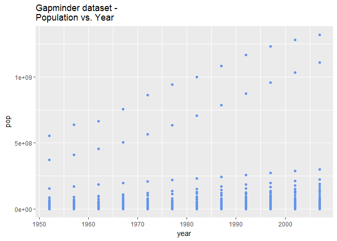

```r
ggplot(gapminder,
      aes(x=year, y=pop)) +
      geom_point(size = 1.5, color = "cornflowerblue") + # customization
      ggtitle("Gapminder dataset - \nPopulation vs. Year")
```

**Tip 2: To add title, layer this onto your ggplot: “+ ggtitle(”Gapminder dataset - Population vs. Year“)”**

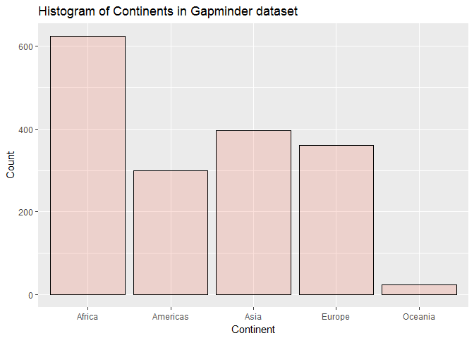

```r
ggplot(data = gapminder, aes(gapminder$continent)) +
  geom_histogram(stat = "count", colour = "black", fill = "coral2", alpha = 0.2) +
  labs(x = "Continent", y = "Count") + # relabel axis
  ggtitle("Histogram of Continents in Gapminder dataset")
```

**Tip 3: Do you like pretty colours like I do? Want to customize your graphs? Not just regular, boring blue but meet cornflower blue. To find a list of preset colours in R click [here](http://www.stat.columbia.edu/~tzheng/files/Rcolor.pdf). You can also specify HEX colours by including them with a hashtag “#FFFFFF”**

### Plot of pop vs. country (without subset)

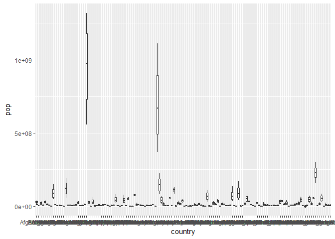

```r
ggplot(gapminder,
      aes(x = country, y = pop)) +
      geom_boxplot()
```

This displays all the countries in the gapminder dataset, which is obviously too many to effectively display in boxplots. In the following step, I use the filter function to subset the data to plot

### Use filter() to subset the above dataset

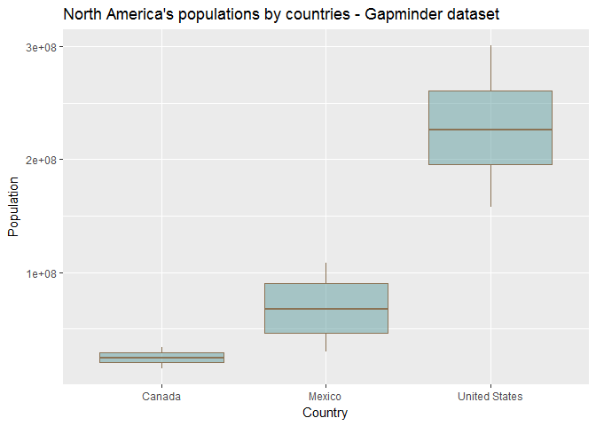

```r
NAmericas <- filter(gapminder, country %in% c("Canada", "Mexico", "United States"))
ggplot(NAmericas,
      aes(x=country, y=pop)) +
      geom_boxplot(colour = "burlywood4", fill = "cadetblue", alpha = 0.5) + #making pretty graphs via fill, line and transparency customization
      ggtitle("North America's populations by countries - Gapminder dataset") +
      labs(x = "Country", y = "Population")
```

**Tip 3: Relabel axis by adding “labs(x =”insert_text_here“, y =”insert_text_here“), insert your own x and y labels**

### Adding it all together: filter, select, piping into ggplot

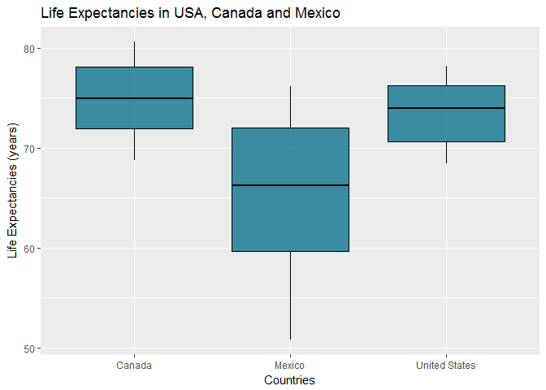

```r
gapminder %>%
  filter(country %in% c("Canada", "Mexico", "United States")) %>%
  select(country, lifeExp) %>%
  ggplot(., aes(x=country, y=lifeExp)) +
  geom_boxplot(fill = "#0f738e", colour = "black", alpha = "0.8") +
  ggtitle("Life Expectancies in USA, Canada and Mexico") +
  labs(x = "Countries", y = "Life Expectancies (years)")
```

**Tip 4: I’ve also learned that to display plots from RMarkdown on GitHub you need to save RMarkdown file as a raw file (.md). Then also commit and push these images to GitHub. [click here](https://github.com/STAT540-UBC/Discussion/issues/11)**